# 4_MachineLearning

## Section 6: Introduction to Machine Learning & Scikit-learn

### Compiled by :

```
               Alem H Fitwi,
               PhD Student (Privacy, Deep Learning, Networking (Edge Computing), IoD, Surveillance Systems),
               GA-Data Analyst,
               Binghamton University-State University of New York
```

A look at:

```
What machine learning means
The concept of supervised and unsupervised learning
Introduction to sckit-learn library in Python
```

### 1.1: Machine Learning

Machine Learning (ML): a subfield of AI that involves self-learning algorithms where a model can learn from data without being explicitly programmed. The model will then be able to predict outcomes of new data (generalization).

"A computer program is said to learn experience E with respect to some class of tasks T and performance measure P, id its performance at tasks T, as measured by P, improves with experience E." -Tom M.Mitchell

Used in many areas: Fraud Detection, Credit approval, Text sentiment analysis, Speech recognition, image recognition, Email spam filtering, Service Recommendation.

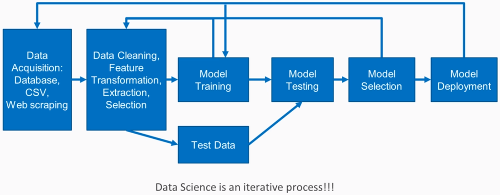

```python
from IPython.display import Image
from IPython.core.display import HTML
Image('ds_4.png')
```

The above figure shows the Machine learning processes

### 1.2: Types of Machine Learning

Types of Machine Learning are are of three broad types:

```
Supervised
Unsupervised
Reinforcement
```

Supervised Learning: Target variable present for training. For example: Regression, Classification (X,y)

Unsupervised Learning: No target variable present. For example: CLustering, Dimensionality reduction (X)

Reinforcement Learning: Reward oriented learning algorithms based on past actions and results.

$X_{1}$, $X_{2}$, ..., $X_{p}$: Independent Variable, Input, Feature, Predictor

Y: Dependent Variable, Outcome, Response

### Regression and Classification

Regression: minimizes the mean square errors

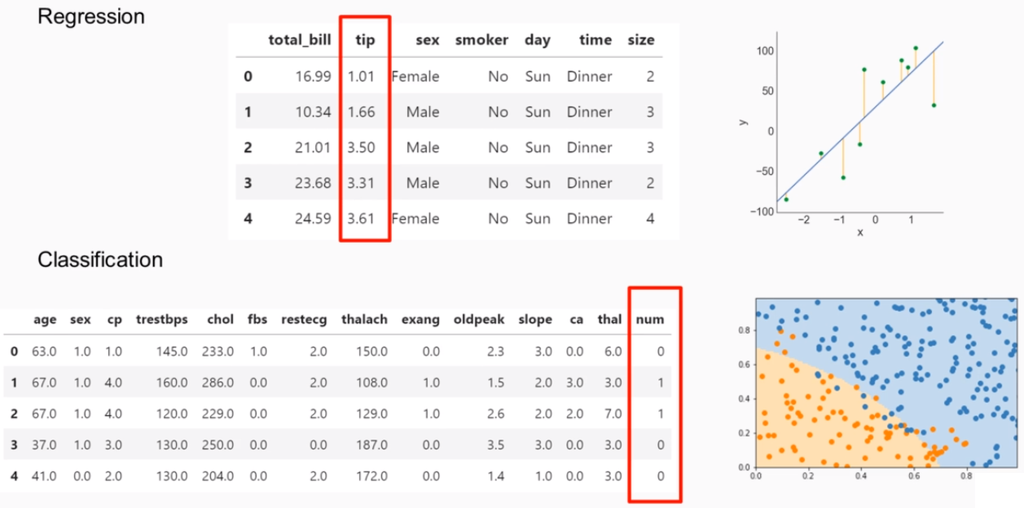

```python
from IPython.display import Image
from IPython.core.display import HTML
Image('ds_5.png')
```

### Unsupervised Learning

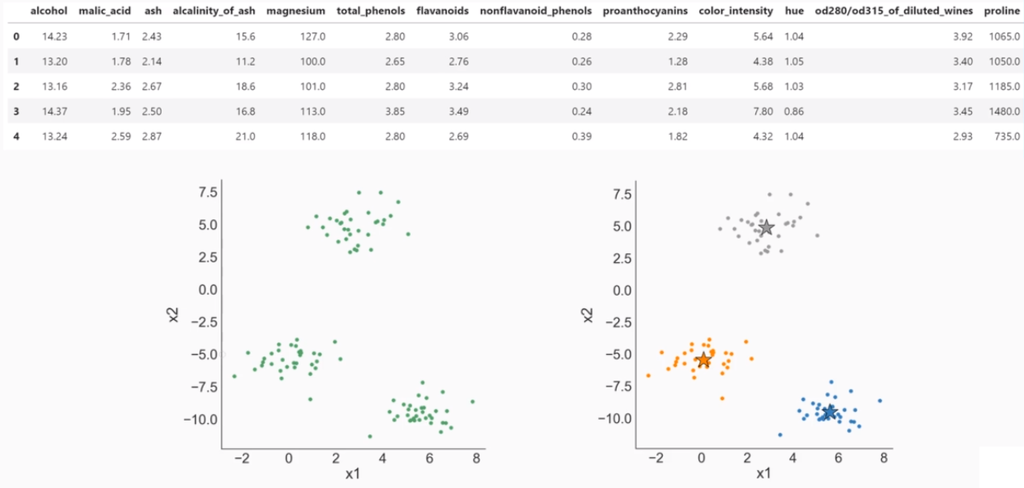

```python
from IPython.display import Image
from IPython.core.display import HTML
Image('ds_6.png')
```

### Reinforcement Learning

Agent interacts with environment and improves its behavior based on feedback/results from the past.

Action - Reaction

Application areas generally involve agent based environments where some sort of reward is present such as games, agent based simulation etc

Differs from supervised learning in that no direct input-output data is present. The outcome might be obtained several steps later which may be in the form of success/failure. The agent then analyzes its past behavior and updates its priorities and plays the game again. This will lead the agent to become better over time.

Trial and error learning method

### 1.3: Introduction to Scikit-learn

A look at:

```
What scikit-learn is
The reuirement for scikit-learn
The general machine learning process in scikit-learn
```

Scikit-learn is a machine learning library for the Python programming language

Can interoperate with Numpy, Scipy, and Pandas

Makes the machine learning stage of data science very easy to implement

Has also capabilities for creating data

The feature matrix and response vector are provided separately (The formula input used in R is not valid in sklearn)

The inputs should be nummeric (Categorical variables are converted to dummy variables)

The rows are observations and the columns are features (tabular data format)

The feature matrix is N by p pandas DataFrame or N element pandas series or 1D Numpy array.

The output vector can be N by 1 DataFrame or N element pandas series or 1D Numpy array.

Import sklearn Machine Learning Estimator Object. from sklearn.ml_family import ModelName

Instantiate the Estimator with default parameters or change the parameters. model=Model()

Fit the model to the train data. model.fit(X_train, Y_train)

Test the model on the test data. y_pred=model.predict(X_test).

Calculate accuracy and other performance metrics. metrics.score(y_test, y_pred)